# report

Alex Wei

2023-03-15

## Project requirements

I have meet all the requirements for Project 1, besides meeting the deadline.

### Github

I have made a github repository for stats 220.

It houses a “README.md” file which exhibits the use of certain markdown properties as outline in the Project requirements as described in **PART A**.

“index.html” which I made following Project 1’s instructions is hosted on the same github repository.

### Memes and .gifs

I have made a meme and a .gif animation following the Project 1’s requirements for **PART B** and **PART C**

meme.R and animation.R both exhibit the relevant qualities of using the “magick” library, other required functions, naming objects, using pipes, indenting lines, and leaving comments.

These 2 forms of media were implemented into the HTML page.

### index.html

“index.html” is required as dictated in **PART D**.

I have included two chunks which have the relevant codes showing the creation of the meme and animation right below the respective meme and animation.

I used CSS to further distinguish the headers and centred the meme.

### Links and Screenshots

Github repository: https://github.com/TheDaDao/stats220  
Website link: https://thedadao.github.io/stats220/

[figure not shown]

Project 1 file screenshot Note the file “Project1.Rproj” which shows that I have used R studio. (Visual studio code seems to be the default despite me having used Rstudio for all coding with R project.)

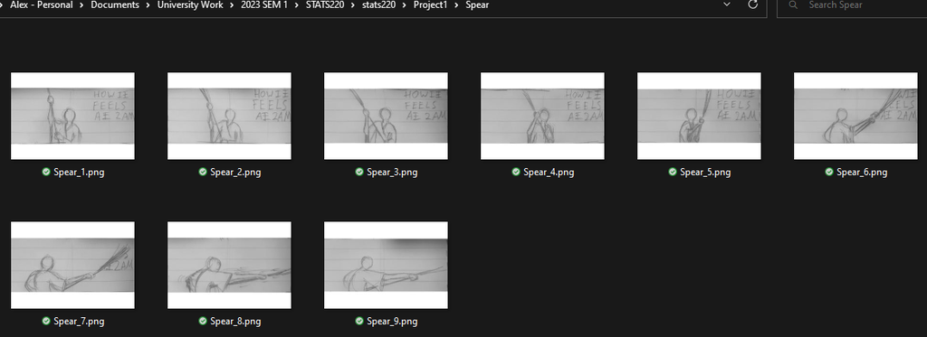

Screenshot of the frames of animation.

### Demonstrating Creativity

I added a further 5 frames for the animation and hand drawn them at 1 AM in 30 minutes. Drawing this animation of a person swinging a glaive/spear is a way of expressing creativity.

## Learning Reflection

One important idea I learnt from this course is that you can use mutltiple technologies on a singular goal. This project would be an example of me learning to integrate HTML and R project into one cohesive system, where I can make media using R and implementing them in a primitive website made on the same software (R Studio). The data manipulation abilities of R Project allows data to be better represented when integrated with technologies such as HTML and CSS.

What I am curious about exploring further is how different technologies can interact with each other. What if there were more than just R project and HTML? The power behind this more complicated system allows for even more options for gathering, processing, and representing Data. Another thing about data technologies I am interested in is using R project in data science and other functions which R Project may have.